# Analise_de_Gastos_de_Deputados

Vinicius Brandão

```r
library(readr)
library(tidyverse)
library(lubridate)
options(scipen = 999)
```

## Descrição do Problema

Analise realizada para a disciplina de Ciência de dados Preditiva (Periodo: 2018.2) e tem como principal objetivo responder determinadas perguntas sobre o conjunto de dados referentes a gastos de deputados relacionados a atividade parlamentar utilizando o CEAP(cota para o exercício da atividade parlamentar).

**Ceap:** É uma cota única mensal destinada a custear os gastos dos deputados exclusivamente vinculados ao exercício da atividade parlamentar. Exemplos de despesa desse tipo são: passagens aéreas, telefonia, serviços postais, manutenção de escritórios de apoio à atividade parlamentar, assinatura de publicações, fornecimento de alimentação ao parlamentar, hospedagem, outras despesas com locomoção, contemplando locação ou fretamento de aeronaves, veículos automotores e embarcações, serviços de táxi, pedágio, estacionamento e passagens terrestres.

### Perguntas a ser respondidas na analise:

1. Quais são os deputados que gastaram mais dinheiro da CEAP? Quais são os mais econômicos?
2. Quais os estados cujos deputados gastam mais no exterior? Quais os estados cujos deputados gastam menos no exterior?
3. Quais os partidos cujos parlamentares mais usam CEAP no estado da Paraíba? Quais são os que menos usam? Mesmas perguntas considerando valores em R$
4. Quais os deputados que mais ultrapassam o limite de CEAP do seu estado?
5. Quais estados cujos parlamentares gastam mais com passagens aéreas?
6. Escolha três partidos e responda: Quais são os tipos de despesa mais utilizados no uso da CEAP pelos deputados desses partidos? Mesma pergunta considerando valores em R$.

### Descrição dos dados

Os dados foram coletados do site de transparência da Câmara e foram tratados. Também foi considerado um conjunto de dados contendo o limite do CEAP por estado.

```r
date <- read_csv(here::here("date/dadosCEAP.csv"),
                 progress = F,
                 col_types = cols(
                   nomeParlamentar = col_character(),
                   idCadastro = col_integer(),
                   sgUF = col_character(),
                   sgPartido = col_character(),
                   tipoDespesa = col_character(),
                   especDespesa = col_character(),
                   fornecedor = col_character(),
                   CNPJCPF = col_character(),
                   tipoDocumento = col_integer(),
                   dataEmissao = col_character(),
                   valorDocumento = col_double(),
                   valorGlosa = col_integer(),
                   valorLíquido = col_double())) %>%
  mutate(dataEmissao = parse_date_time(dataEmissao,"%Y-%m-%d %H:%M:%S"),
         year_month = paste(lubridate::year(dataEmissao),
                            lubridate::month(dataEmissao),sep = "-"),
         tipoDespesa = toupper(tipoDespesa))
limiteCeap <- read_csv("../date/limiteMensalCEAP.csv")
date %>%
  full_join(limiteCeap, by = c("sgUF" = "UF")) -> date
```

Uma descrição sobre as colunas dos dados se encontra abaixo:

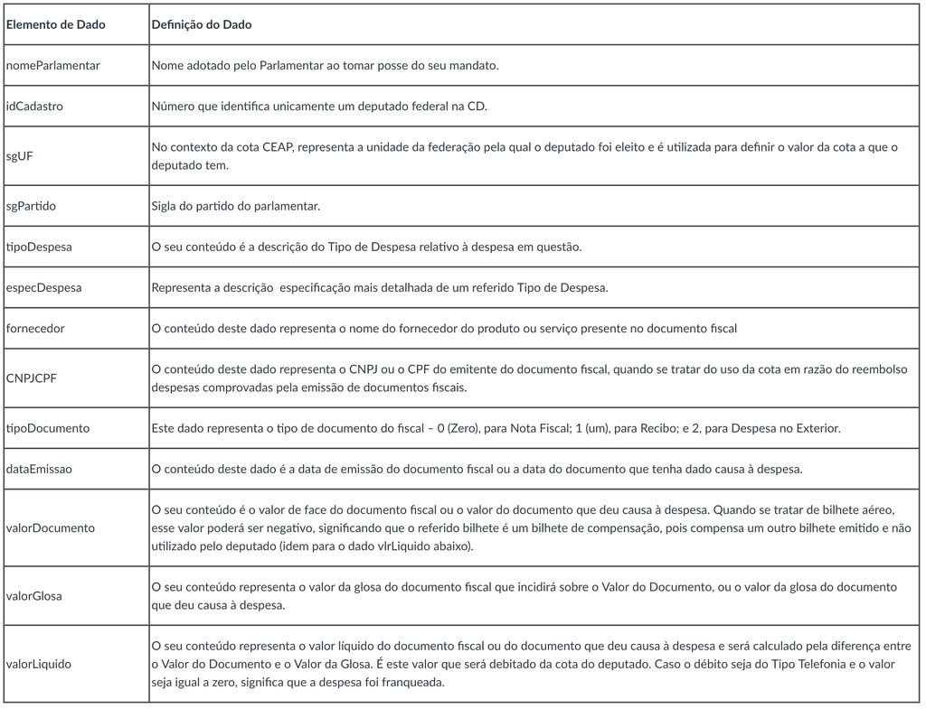

## Quais são os deputados que gastaram mais dinheiro da CEAP? Quais são os mais econômicos?

Para responder essa pergunta iremos separar em dois grupos considerando os que mais gastaram e o que menos gastaram e assim gerar um Top 3 respectivamente de cada grupo.

```r
gastadores <- date %>%
              group_by(nomeParlamentar) %>% #Agrupando por nome
              summarise(total = sum(valorLíquido)) %>% #Criando a o valor total referendo aos gastos
              arrange(-total) %>% # Ordenado do maior para o menor
              slice(1:3) # Retirando o top 3.

economistas <- date %>%
              group_by(nomeParlamentar) %>% #Agrupando por nome
              summarise(total = sum(valorLíquido)) %>% #Criando a o valor total referendo aos gastos
              filter(total >= 0) %>% # Filtrando os valores negativos
              arrange(total) %>% # Ordenado do menor para o maior
              slice(1:3) # Retirando o top 3.

parlamentares <- full_join(gastadores,economistas) #Dando merge nos dois dataset
```

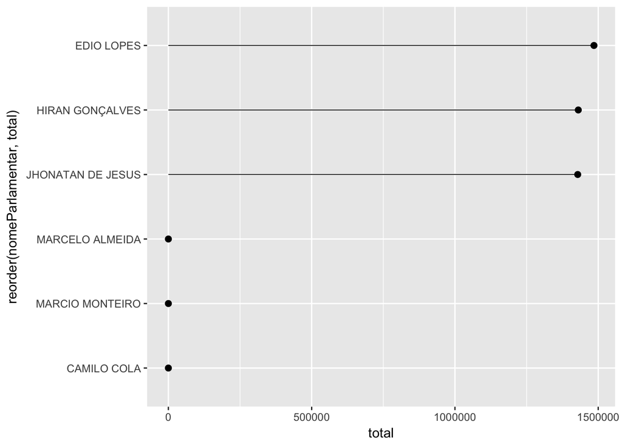

```r
parlamentares %>% ggplot(aes(x =  reorder(nomeParlamentar,total), y = total, ymax = total, ymin = 0)) +
   geom_point(size = 2) +
    geom_linerange(size = .3) +
   coord_flip()
```

Observamos os 3 parlamentares que mais gastaram vemos que as suas despesas ultrapassam 1 milhão de reais, sendo assim, considerando um salário bruto de R$ 26.723,12 podemos observar que só em cota parlamentar tais parlamentares chegaram a gastar cerca de 55 vezes mais do que seu salário bruto. Como podemos observar existe uma disparidade entre o que mais gastaram e o que menos gastaram, nesse caso observamos que não ficou muito intuitivo a visualização dos parlamentares que menos gastaram para iremos gerar um novo gráfico para observar a diferença.

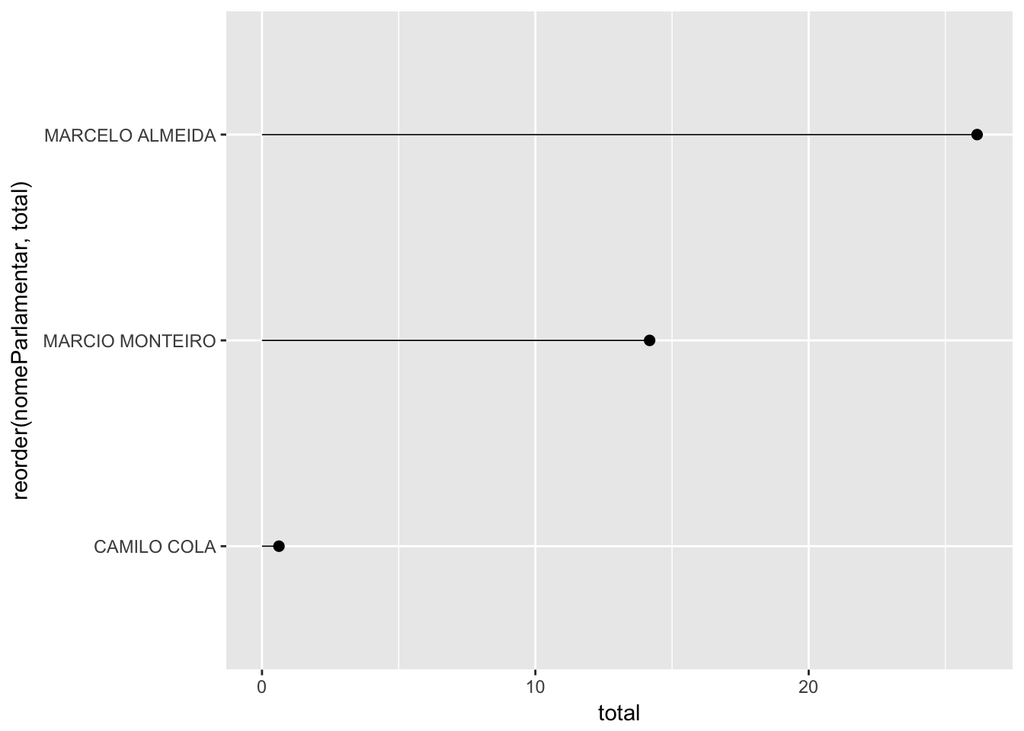

```r
economistas %>%  ggplot(aes(x =  reorder(nomeParlamentar,total), y = total, ymax = total, ymin = 0)) +
   geom_point(size = 2) +
    geom_linerange(size = .3) +
   coord_flip()
```

## Quais os estados cujos deputados gastam mais no exterior? Quais os estados cujos deputados gastam menos no exterior?

Para responder essa pergunta iremos observar o gasto com essa despesa considerando o seu tipo, para essa pergunta iremos utiliza o tipoDocumento = 2, onde se refere a despesa no exterior, e assim considerando os estados para observar qual o que mais gastou com essas despesas.

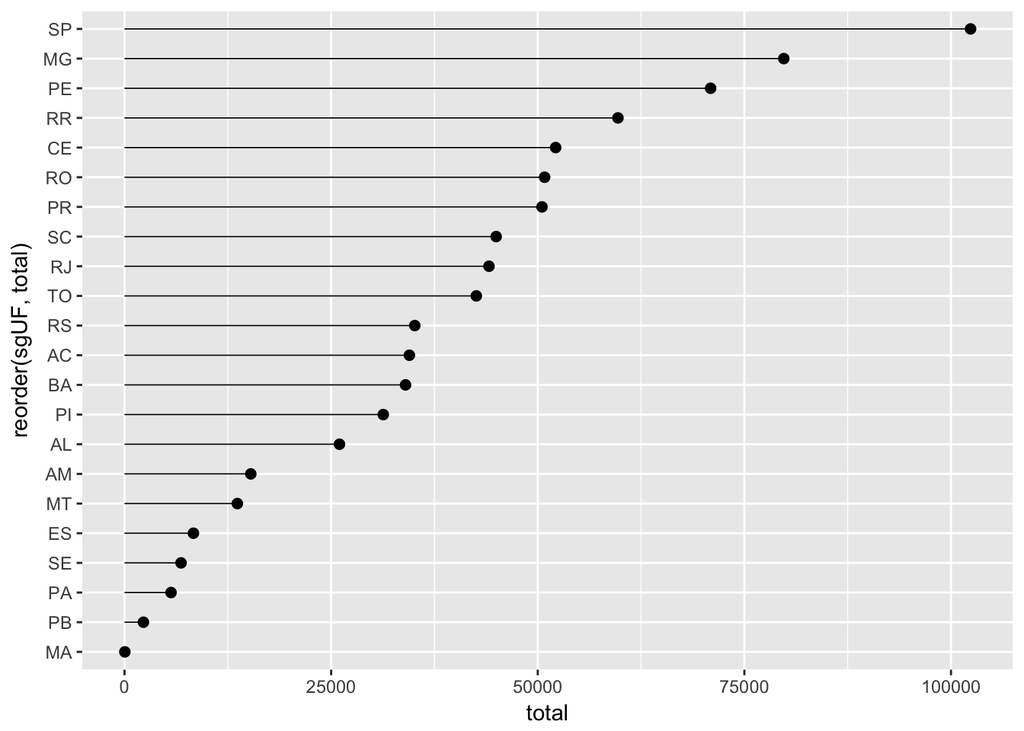

```r
estadoExterior <- date %>%
            filter(tipoDocumento == 2) %>% #Filtrando pelo tipo de documento 2 == Despesa exterior
            group_by(sgUF) %>% # Filtrando por Estado
              summarise(total = sum(valorLíquido)) %>% #Criando a o valor total referendo aos gastos daquele tipo de despesa
              arrange(-total) # Ordenado do maior para o menor



estadoExterior %>% ggplot(aes(x =  reorder(sgUF,total), y = total, ymax = total, ymin = 0)) +
   geom_point(size = 2) +
    geom_linerange(size = .3) +
   coord_flip()
```

Para essa pergunta iremos filtrar todas as despesas relacionado a parlamentares do estado da Paraíba e assim vê de acordo com os partidos quais mais gastou.

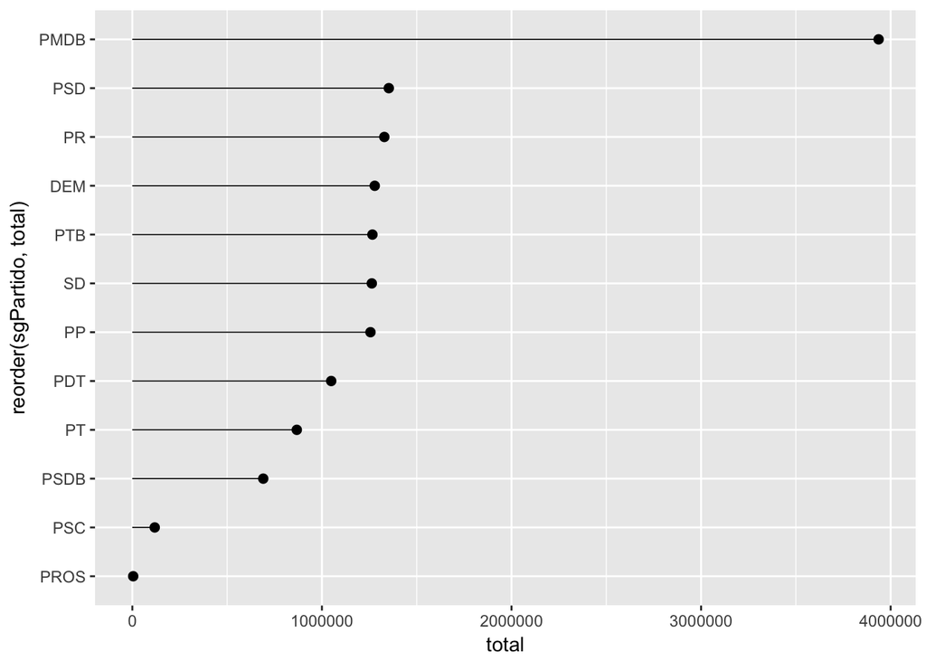

```r
partidosgastadores <- date %>%
                      filter(sgUF == "PB") %>% # Filtrando pelo estado da PB
                      group_by(sgPartido) %>% # Agrupando por partido
                      summarise(total = sum(valorLíquido)) %>% #Criando a o valor total referendo aos gastos
                      arrange(-total) # Ordenado do maior para o menor

partidosgastadores %>% ggplot(aes(x =  reorder(sgPartido,total), y = total, ymax = total, ymin = 0)) +
   geom_point(size = 2) +
    geom_linerange(size = .3) +
   coord_flip()
```

Como podemos observar o PMDB é o partido que mais gasta no estado da Paraíba, com uma diferença bem considerável em relação aos demais.

Iremos analisar o porquê de toda essa diferença, uma das coisas que analisamos é o número de parlamentares desse partido no estado da Paraíba.

Para observar o número de candidatos observamos está tabela e vê como anda a distribuição desse.

```r
date %>%
     filter(sgUF == "PB") %>% # Filtrando pelo estado da PB
      group_by(sgPartido,nomeParlamentar) %>% # Agrupando por nome e partido do candidato
      summarise(count = n()) # Contando quantas requisiões de despesas
```

```
## # A tibble: 17 x 3
## # Groups:   sgPartido [?]
##    sgPartido nomeParlamentar         count
##    <chr>     <chr>                   <int>
##  1 DEM       EFRAIM FILHO             1418
##  2 PDT       DAMIÃO FELICIANO         1291
##  3 PMDB      ANDRÉ AMARAL              546
##  4 PMDB      HUGO MOTTA               1255
##  5 PMDB      MANOEL JUNIOR            1075
##  6 PMDB      NILDA GONDIM               30
##  7 PMDB      VENEZIANO VITAL DO RÊGO  1146
##  8 PP        AGUINALDO RIBEIRO        2156
##  9 PR        WELLINGTON ROBERTO       1821
## 10 PROS      MAJOR FÁBIO                22
## 11 PSC       MARCONDES GADELHA         101
## 12 PSD       RÔMULO GOUVEIA           1606
## 13 PSDB      PEDRO CUNHA LIMA          922
## 14 PSDB      RUY CARNEIRO                7
## 15 PT        LUIZ COUTO               1249
## 16 PTB       WILSON FILHO             1250
## 17 SD        BENJAMIN MARANHÃO        1760
```

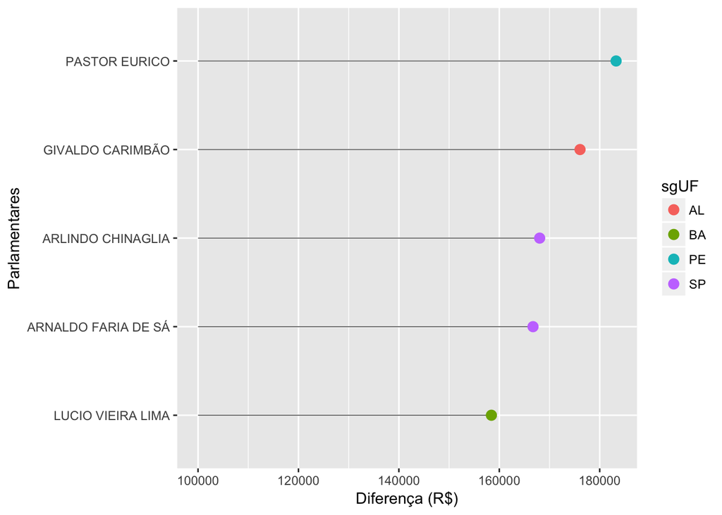

```r
date %>%
  group_by(sgUF,idCadastro,year_month,
           nomeParlamentar,limite_mensal) %>%   #Agrupando por Estado,idCadastro,Mês-Ano,Nome do parlamentar e Limite Mensal
  summarise(total = sum(valorLíquido)) %>%  #Criando a o valor total referendo aos gastos
  filter(year_month != "NA-NA") %>%  # Retirando os Mês-Ano == "NA-NA"
  filter(total > limite_mensal) %>%  # Filtrando os parlamentares que ultrapassaram seu limite mensal por mês
  ungroup()  -> candidatos_mes_ano # Atribuindo ao data set candidatos_mes_ano

candidatos_mes_ano %>%
  group_by(idCadastro,nomeParlamentar) %>% # Agrupando pelo id e nome do parlamentar
  arrange(desc(total)) %>%   #Ordenando do maior para o menor
  slice(1) %>%
  ungroup() %>%
  top_n(n=5, wt=total) %>%  #Selecionando um top 5
  mutate(diferenca = total - limite_mensal) %>% # Variavel diferença se refe a difereça entre o limite mensal e o total gasto no mês.
  ggplot(aes(diferenca,
             reorder(nomeParlamentar,
                     diferenca))) +
  geom_segment(aes(x = 1E5,
                   y =reorder(nomeParlamentar,
                              diferenca),
                   xend = diferenca,
                   yend = nomeParlamentar),
               color = "grey50",
               size=0.35) +
  geom_point(aes(color=sgUF),size=3) +
  labs(x="Diferença (R$)",
       y="Parlamentares")
```

Podemos observar 5 parlamentares que ultrapassaram os valores do CEAP referente ao seu estado em único mês, sendo assim observamos que todos os 5 ultrapassam a quantia de R$ 140.000,00 reais em relação ao limite do seu respectivo estado. O pastor eurico chega ultrapassa a quantia de RS 180.000,00 referente a um único mês o limite do ceap do seu estado de Pernambuco que é o valor de R$ 41.676,80

## Quais estados cujos parlamentares gastam mais com passagens aéreas?

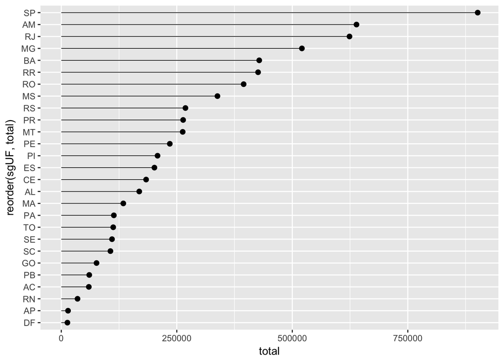

```r
estadosviajados <- date %>% filter(tipoDespesa == "PASSAGENS AÉREAS") %>%  # Filtrando por despesa do tipo passagem area
                   group_by(sgUF) %>% # Filtrando por estado
                    summarise(total = sum(valorLíquido)) %>% na.omit()  # Soma do total de gasto com passagem por estado omitindo NA

estadosviajados %>% ggplot(aes(x =  reorder(sgUF,total), y = total, ymax = total, ymin = 0)) +
   geom_point(size = 2) +
    geom_linerange(size = .3) +
  scale_size_date() +
   coord_flip()
```

Observamos que o estado de São Paulo é o que mais gasta com esse tipo de despesa, mas considerando o número de parlamentares deste estado (70 parlamentares) e os mês presente neste conjunto de dados, e o considerando o preço médio dos gastos desse tipo de despesa que foi de R$ 997.68 e o preço médio de uma passagem ida e volta de São Paulo a Brasília (cidade onde se localiza a câmara dos deputados) o valor demonstrado não aparenta ter uma irregularidade. Por outro lado, o estado do Amazonas é o segundo que mais gasta com esse tipo de despesa e tal estado só possui 8 parlamentares na câmara o que leva a uma investigação um pouco mais relevante para descobrir o porquê do valor tão alto. Para isso, vamos separar esse estado e observar o número de vezes que os seus parlamentares viajaram.

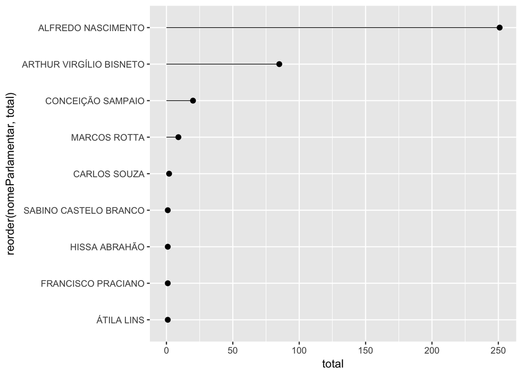

```r
am <-  date %>% filter(tipoDespesa == "PASSAGENS AÉREAS", sgUF == "AM") #Filtrando por tipo de despesa e estado desejado

am <- am %>% group_by(nomeParlamentar,tipoDespesa) %>% #Agrupando por parlamentar
      summarise(total = n()) #Soma da quantidade de vezes dessa despesa por parlamentar

am %>% ggplot(aes(x =  reorder(nomeParlamentar,total), y = total, ymax = total, ymin = 0)) +
   geom_point(size = 2) +
    geom_linerange(size = .3) +
  scale_size_date() +
   coord_flip()
```

Como podemos observar o parlamentar Alfredo nascimento chegou a realizar 251 viajens, em média chega a fazer 8 viajens por mês. Ao certo não sabemos afirmar se tais viajens são realmente validas com o trabalho desenvolvido pelo parlamentar mas indetificamos como um grande outline que obteve grande peso em relação a distribuição por estado em relação aos gastos.

Em relação ao estado que menos gastou observamos o Distrito Federal, algo que considero como o correto dado que a camera dos deputados se encontra no Distrito Federal os parlamentares desse estado não devia ter gastos considerado com esse tipo de despesa.

## Escolha três partidos e responda: Quais são os tipos de despesa mais utilizados no uso da CEAP pelos deputados desses partidos? Mesma pergunta considerando valores em R$

Para responder essa pergunta, escolhi tais partidos:

- PT
- PSDB
- PMDB

Tais partidos foram escolhidos considerando sua força política no pais e numero de parlamentares que o compõe.

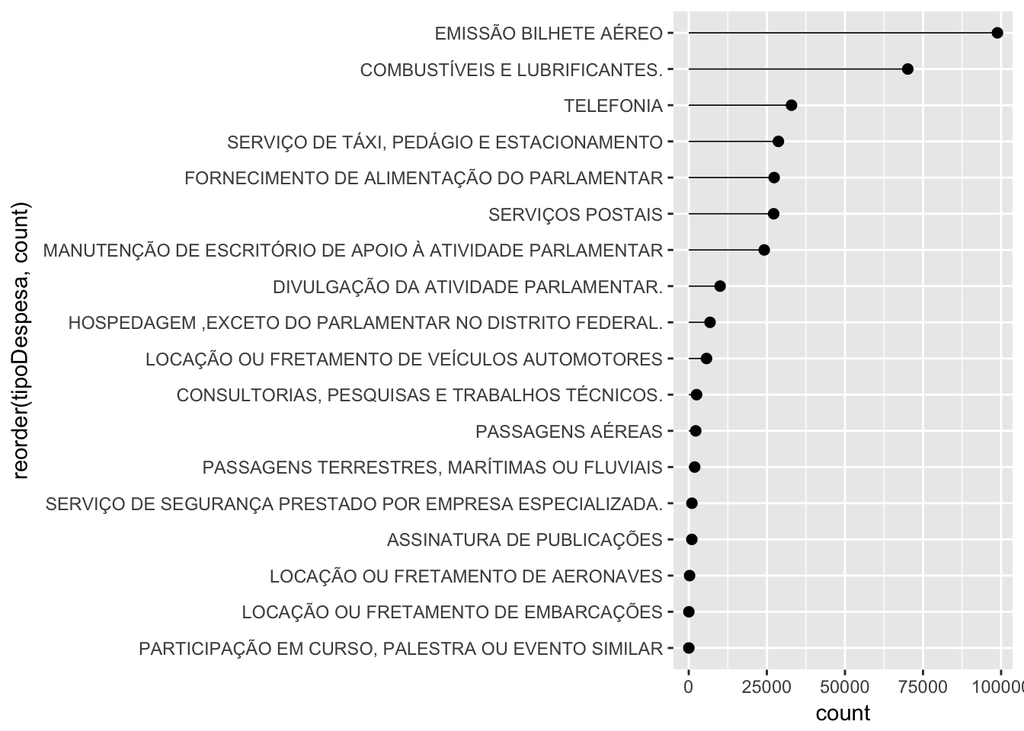

```r
partidos <- date %>% filter(sgPartido %in% c("PT","PSDB","PMDB")) #Filtrando os 3 partidos escolhidos

despesasCeap <- partidos %>% group_by(tipoDespesa) %>% summarise(count = n()) # Contando a quantidade de vezes que a despesa foi requerida

despesasCeap %>% ggplot(aes(x =  reorder(tipoDespesa,count), y = count, ymax = count, ymin = 0)) +
   geom_point(size = 2) +
    geom_linerange(size = .3) +
   coord_flip()
```

Como podemos observar a despesa de “Emissão de bilhete Aéreo” como a despesa mais recorrente entre esses partidos, em seguida por “Combustiveis e lubrificantes” e “Telefonia”, vale reforça que os valores (refere)-se a quantidade de vezes que tais despesas forão requisitadas pelos parlamentares desses partidos. Para descobrir o valor em real que tais despesas tiveram, veremos o gráfico abaixo:

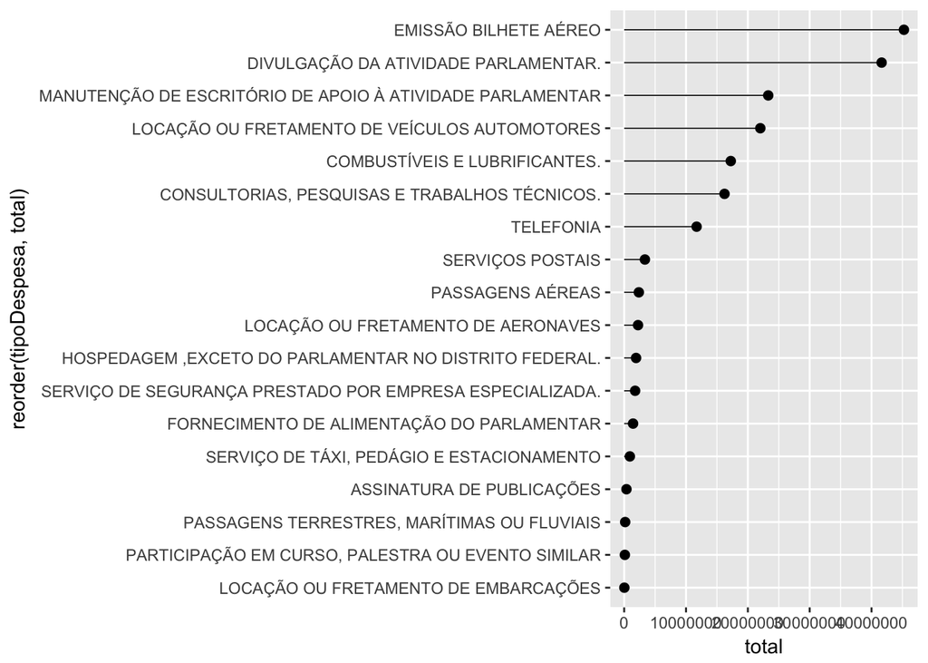

```r
despesasReais <- partidos %>% group_by(tipoDespesa) %>% summarise(total = sum(valorLíquido)) # Selecionando a despesa e a soma de gasto por ela.

despesasReais %>% ggplot(aes(x =  reorder(tipoDespesa,total), y = total, ymax = total, ymin = 0)) +
   geom_point(size = 2) +
    geom_linerange(size = .3) +
   coord_flip()
```

Como podemos vê “Emissão Bilhete Aéreo” é o que mais gera despesa em reais, porém as despesas como “Combustiveis e lubrificantes” e “Telefonia” que são as que mais são requisitadas não estão entre as que mais gastam em valores em reais, podemos observar que a despesa de “Divulgação da Atividade Parlamentar” que ocupa a segunda posição de gastos em reais ela mesmo não sendo tão requisitada como mostramos no gráfico anterior ela é uma despesa que gera muito gasto em valor de real.